# 1.2 Figure 2 Appendix all years

TG

2023-06-27

same as Fig 2 but with all the data since 2015, species in the family level (no 2017)

```r
library(dplyr)
library(tidyr)
library(lubridate)
library(ggplot2)
library(stringr)
library(Hmisc)
library(vegan)
library(mobr)
library(lme4)
library(lmerTest)
library(MuMIn)
library(plotrix)


color_op6_l <- c("#B66DAF","#7CE171","#20A39E","#23001E","#FFBA49","#EF5B5B")

save_path<-"G:\\My Drive\\PHD\\chapter 1 strom effect\\R_storm_ms\\plots\\Fig 2\\Appendix all years"
```

In this script ill concentrate all the models and plot constructing Fig 2

# Data prepartion

```r
load("fish_full_data.rdata")
select <- dplyr::select

fish_prep<-fish_full_data
```

## general steps:

1. keep all years exept 2017

```r
fish_prep <- fish_full_data %>% filter(Year!=2017)
```

2. remove irregular sites

```r
knolls_to_remove<-c("South bridge reserve","North bridge reserve","south bridge reserve",
                    "Tamar","north bridge reserve")

fish_prep<-fish_prep %>% filter(!Knoll %in% knolls_to_remove) %>% filter(Site !="North beach")
```

3. keep one observer from each knoll

```r
one_observer<-list()
loop<-1
set.seed(1)

for (i in unique(fish_prep$survey_id)) {

  data <- fish_prep %>% filter(survey_id == i)

  obs_amount <- length(unique(data$Observer))
  obs_name <- unique(data$Observer)
  chosen_obs <- sample(obs_name,1)

  filter_data<-data %>% filter(Observer == chosen_obs)
  one_observer[[loop]]<-filter_data
  loop<-loop+1


}

fish_prep <- bind_rows(one_observer)

rm(data,filter_data,one_observer)

# make sure i have the right knolls number


knoll_site_year <-fish_prep %>% group_by(Site,year_month) %>% summarise("knoll_number"= n_distinct(knoll_id))
```

4. keep only the resident fish

```r
fish_prep <- fish_prep %>% filter(Status != "T")
```

5. convert year_month to factor

```r
fish_prep$year_month<-as.factor(fish_prep$year_month)
```

6. create the data for species richness, abundance and shannon model

General stepes: 1. add confisance to data before 2018

2. filter accourding to confidance level (richness and eveness; confidance = 0, abundance; confidance = 2)
3. filter schools for eveness
4. group by the right variable (number of species/ind/effective number)

```r
#early years didnt have confidance

fish_prep$Confidence[is.na(fish_prep$Confidence)]<-(0)
```

### richness

```r
richness <- fish_prep %>% filter(Confidence < 1)

richness<- richness %>%
  group_by(survey_id) %>%
  mutate(Species_number = n_distinct(Species_2015)) %>%
  select(-Species,-Species_2015,-Family,-Abundance,-Length,-Confidence,-Status,-a,-b) %>%
  ungroup() %>%
  distinct(.keep_all = T)
```

### abundance

```r
abundance <- fish_prep %>%
  group_by(survey_id,Site,Knoll,year_month,Max_depth,Min_depth,Mean_Complexity,
           Surface_Area,Algae,coral_cover) %>%
    summarise("ind"=sum(Abundance))
```

```
## 'Max_depth', 'Min_depth', 'Mean_Complexity', 'Surface_Area', 'Algae'. You can
```

```r
which(!abundance$survey_id %in% richness$survey_id)
```

```
## integer(0)
```

### Shannon

first - filter and convert to wide data format

chand to the school fish name that valid for 2015

Pseudanthias squamipinnis == Pseudanthias spp.

Atherinomorus lacunosus == Atherinidae

Spratelloides gracilis == Spratelloididae

```r
school_species <- c("Chromis viridis",
                    "Pseudanthias spp.",
                    "Neopomacentrus miryae",
                    "Atherinidae",
                    "Spratelloididae")

shannon <- fish_prep %>% filter(! Species_2015 %in% school_species) %>% filter(Confidence < 1)


shannon <- shannon %>%
  group_by(Site,Year,year_month,Knoll,DD_X,DD_Y,Surface_Area,Max_depth,Date,survey_id,Species_2015) %>%
  summarise("aboundance"=sum(Abundance))
```

```
## 'DD_X', 'DD_Y', 'Surface_Area', 'Max_depth', 'Date', 'survey_id'. You can
```

```r
shannon<-spread(shannon,Species_2015,aboundance,fill = 0)

which(!abundance$survey_id %in% shannon$survey_id) # need to be 1, transect "Caves_11_2020-06-14" had only schooling core species
```

```
## [1] 15
```

calculate the shannon effective number

```r
shannon$shannon_div<-diversity(shannon[,11:ncol(shannon)],index="shannon")

shannon<-shannon %>%
  relocate(shannon_div,.after=survey_id) %>%
  mutate("shannon_effective"=exp(shannon_div),.after=shannon_div)
```

# Models

## Richness model

```r
richness_model<-lm(formula = log(Species_number) ~ log(Surface_Area)*year_month ,data = richness)

summary(richness_model)
```

```
##
## Call:
## lm(formula = log(Species_number) ~ log(Surface_Area) * year_month,
##     data = richness)
##
## Residuals:
##      Min       1Q   Median       3Q      Max
## -2.33907 -0.19363  0.04651  0.23590  0.93304
##
## Coefficients:
##                                    Estimate Std. Error t value Pr(>|t|)
## (Intercept)                         1.01348    0.31281   3.240  0.00129 **
## log(Surface_Area)                   0.49411    0.11017   4.485 9.52e-06 ***
## year_month2016 b                    0.25524    0.38758   0.659  0.51057
## year_month2018 b                    0.66516    0.38411   1.732  0.08409 .
## year_month2020 a                   -1.62330    0.38804  -4.183 3.53e-05 ***
## year_month2020 b                    0.13588    0.36372   0.374  0.70891
## year_month2021 a                   -0.16661    0.36372  -0.458  0.64715
## log(Surface_Area):year_month2016 b -0.11594    0.13625  -0.851  0.39530
## log(Surface_Area):year_month2018 b -0.19299    0.13520  -1.427  0.15423
## log(Surface_Area):year_month2020 a  0.39578    0.13626   2.905  0.00388 **
## log(Surface_Area):year_month2020 b -0.04688    0.12829  -0.365  0.71499
## log(Surface_Area):year_month2021 a  0.05777    0.12829   0.450  0.65273
## ---
## Signif. codes:  0 '***' 0.001 '**' 0.01 '*' 0.05 '.' 0.1 ' ' 1
##
## Residual standard error: 0.3768 on 404 degrees of freedom
## Multiple R-squared:  0.4952, Adjusted R-squared:  0.4814
## F-statistic: 36.02 on 11 and 404 DF,  p-value: < 2.2e-16
```

```r
r.squaredGLMM(richness_model)
```

```
##            R2m       R2c
## [1,] 0.4884502 0.4884502
```

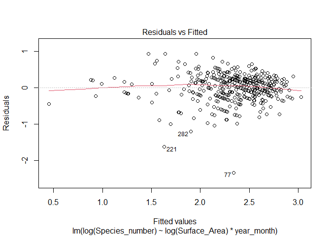

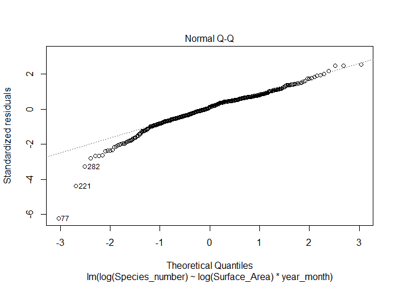

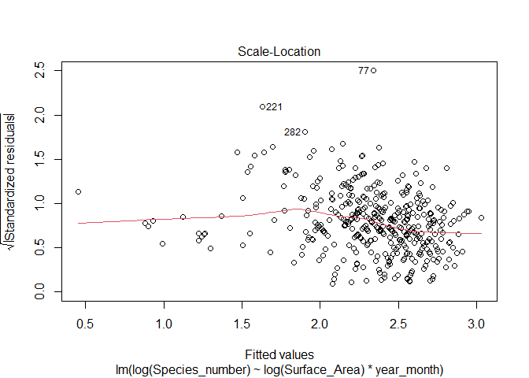

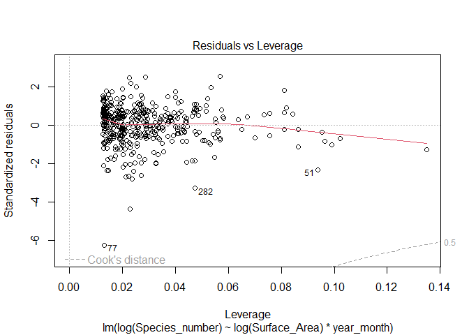

```r
plot(richness_model)
```

```r
richness_model_gg = ggeffects::ggpredict(richness_model,terms = c('Surface_Area[1:66 by=1]','year_month'))
```

```
## Model has log-transformed response. Back-transforming predictions to
##   original response scale. Standard errors are still on the log-scale.
```

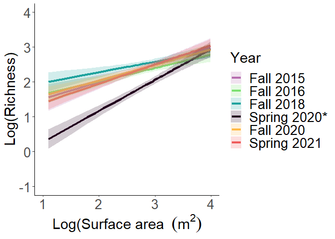

```r
ggplot()+
  theme_classic()+
  geom_line(data = richness_model_gg,aes(x= log(x),y = log(predicted),color= group),size=1.5)+
  geom_ribbon(data = richness_model_gg,aes(x=log(x),ymin=log(conf.low),ymax=log(conf.high),fill=group),alpha=0.2)+
  ylab("Log(Richness)")+xlim(1,4)+ylim(-1,4)+
  xlab(bquote('Log(Surface area '~(m^2)))+
    theme(axis.text.x = element_text(size=20),
        axis.text.y = element_text(size =20),
        axis.title.x = element_text(size=22),
        axis.title.y = element_text(size=22),
        legend.title = element_text(size=22),
        legend.text = element_text(size=20),
        strip.text.x = element_text(size = 20))+
        scale_color_manual(values=color_op6_l,
                           name = "Year",
                           labels = c("Fall 2015","Fall 2016","Fall 2018","Spring 2020*", "Fall 2020" ,
                                      "Spring 2021"))+
        scale_fill_manual(values=color_op6_l,
                           name = "Year",
                           labels = c("Fall 2015","Fall 2016","Fall 2018","Spring 2020*", "Fall 2020" ,
                                      "Spring 2021"))
```

```r
#ggsave("Area_richness_15.png" , width = 12, height = 5, dpi = 300,path = save_path)
#ggsave("Area_richness_15.pdf" , width = 12, height = 5, dpi = 300,path = save_path)
```

## Abundance model

```r
abundance_model<-lm(formula = log(ind) ~ log(Surface_Area)*year_month,data = abundance)
summary(abundance_model)
```

```
##
## Call:
## lm(formula = log(ind) ~ log(Surface_Area) * year_month, data = abundance)
##
## Residuals:
##      Min       1Q   Median       3Q      Max
## -2.56849 -0.75784  0.03554  0.76962  2.56127
##
## Coefficients:
##                                    Estimate Std. Error t value Pr(>|t|)
## (Intercept)                         1.36475    0.85238   1.601 0.110135
## log(Surface_Area)                   1.15932    0.30022   3.862 0.000131 ***
## year_month2016 b                    0.71470    1.05615   0.677 0.498981
## year_month2018 b                    1.39578    1.04668   1.334 0.183108
## year_month2020 a                   -2.43341    1.05738  -2.301 0.021880 *
## year_month2020 b                    0.47180    0.99113   0.476 0.634317
## year_month2021 a                    0.51185    0.99113   0.516 0.605836
## log(Surface_Area):year_month2016 b -0.16358    0.37126  -0.441 0.659736
## log(Surface_Area):year_month2018 b -0.34732    0.36841  -0.943 0.346370
## log(Surface_Area):year_month2020 a  0.51364    0.37129   1.383 0.167308
## log(Surface_Area):year_month2020 b -0.17772    0.34959  -0.508 0.611464
## log(Surface_Area):year_month2021 a -0.09689    0.34959  -0.277 0.781798
## ---
## Signif. codes:  0 '***' 0.001 '**' 0.01 '*' 0.05 '.' 0.1 ' ' 1
##
## Residual standard error: 1.027 on 404 degrees of freedom
## Multiple R-squared:  0.377,  Adjusted R-squared:  0.3601
## F-statistic: 22.23 on 11 and 404 DF,  p-value: < 2.2e-16
```

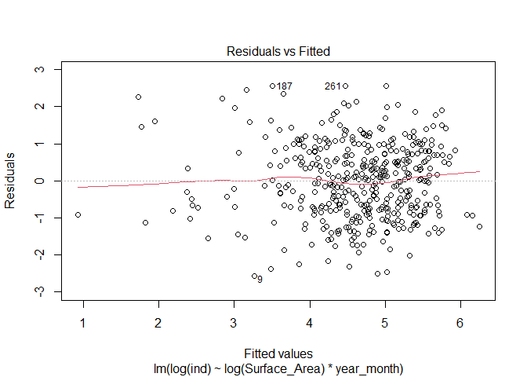

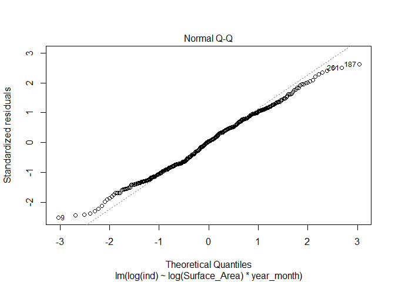

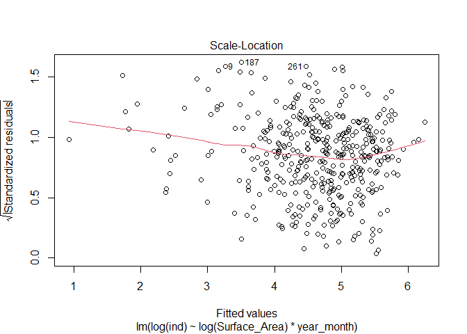

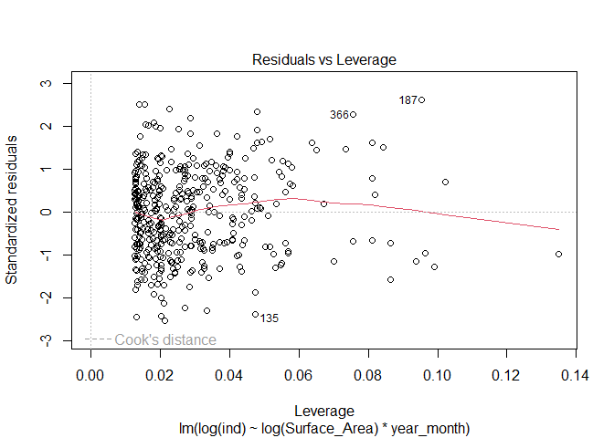

```r
plot(abundance_model)
```

```r
abundance_model_gg=ggeffects::ggpredict(abundance_model,terms = c('Surface_Area[1:66 by=1]','year_month'))
```

```
## Model has log-transformed response. Back-transforming predictions to
##   original response scale. Standard errors are still on the log-scale.
```

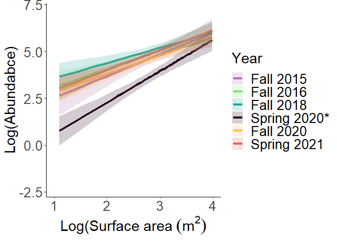

```r
ggplot()+
  theme_classic()+
  geom_line(data = abundance_model_gg,aes(x= log(x),y = log(predicted),color= group),size=1.5)+
  geom_ribbon(data = abundance_model_gg,aes(x=log(x),ymin=log(conf.low),ymax=log(conf.high),fill=group),alpha=0.2)+
  ylab("Log(Abundabce)")+xlim(1,4)+
  xlab(bquote('Log(Surface area'~(m^2)))+
    theme(axis.text.x = element_text(size=20),
        axis.text.y = element_text(size =20),
        axis.title.x = element_text(size=22),
        axis.title.y = element_text(size=22),
        legend.title = element_text(size=22),
        legend.text = element_text(size=20),
        strip.text.x = element_text(size = 20))+
        scale_color_manual(values=color_op6_l,
                           name = "Year",
                           labels = c("Fall 2015","Fall 2016","Fall 2018","Spring 2020*", "Fall 2020" ,
                                      "Spring 2021"))+
        scale_fill_manual(values=color_op6_l,
                           name = "Year",
                           labels = c("Fall 2015","Fall 2016","Fall 2018","Spring 2020*", "Fall 2020",
                                      "Spring 2021"))
```

```r
#ggsave("Area_abundance_15.png" , width = 12, height = 5, dpi = 300,path = save_path)
#ggsave("Area_abundance_15.pdf" , width = 12, height = 5, dpi = 300,path = save_path)
```

## Shannon model

```r
shannon_model<-lm(formula = log(shannon_effective) ~ log(Surface_Area)*year_month,data = shannon)
summary(shannon_model)
```

```
##
## Call:
## lm(formula = log(shannon_effective) ~ log(Surface_Area) * year_month,
##     data = shannon)
##
## Residuals:
##      Min       1Q   Median       3Q      Max
## -1.56809 -0.22866  0.00927  0.26736  1.02908
##
## Coefficients:
##                                    Estimate Std. Error t value Pr(>|t|)
## (Intercept)                         1.55036    0.32263   4.805 2.18e-06 ***
## log(Surface_Area)                   0.04886    0.11363   0.430   0.6675
## year_month2016 b                   -0.26151    0.39975  -0.654   0.5134
## year_month2018 b                   -0.16743    0.39617  -0.423   0.6728
## year_month2020 a                   -2.23843    0.40078  -5.585 4.30e-08 ***
## year_month2020 b                   -0.40677    0.37514  -1.084   0.2789
## year_month2021 a                   -0.93505    0.37514  -2.493   0.0131 *
## log(Surface_Area):year_month2016 b  0.04980    0.14052   0.354   0.7232
## log(Surface_Area):year_month2018 b  0.06828    0.13944   0.490   0.6247
## log(Surface_Area):year_month2020 a  0.70656    0.14062   5.025 7.59e-07 ***
## log(Surface_Area):year_month2020 b  0.13187    0.13232   0.997   0.3196
## log(Surface_Area):year_month2021 a  0.33794    0.13232   2.554   0.0110 *
## ---
## Signif. codes:  0 '***' 0.001 '**' 0.01 '*' 0.05 '.' 0.1 ' ' 1
##
## Residual standard error: 0.3886 on 403 degrees of freedom
## Multiple R-squared:  0.2696, Adjusted R-squared:  0.2496
## F-statistic: 13.52 on 11 and 403 DF,  p-value: < 2.2e-16
```

```r
shannon_model_gg=ggeffects::ggpredict(shannon_model,terms = c('Surface_Area[1:66 by=1]','year_month'))
```

```
## Model has log-transformed response. Back-transforming predictions to
##   original response scale. Standard errors are still on the log-scale.
```

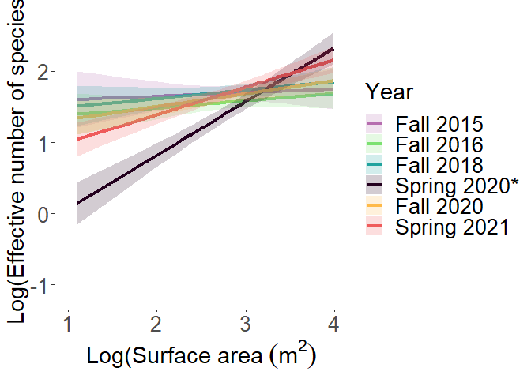

```r
ggplot()+
  theme_classic()+
  geom_line(data = shannon_model_gg,aes(x= log(x),y = log(predicted),color= group),size=1.5)+
  geom_ribbon(data = shannon_model_gg,aes(x=log(x),ymin=log(conf.low),ymax=log(conf.high),fill=group),alpha=0.2)+
  ylab("Log(Effective number of species)")+xlim(1,4)+
  xlab(bquote('Log(Surface area'~(m^2)))+
    theme(axis.text.x = element_text(size=20),
        axis.text.y = element_text(size =20),
        axis.title.x = element_text(size=22),
        axis.title.y = element_text(size=22),
        legend.title = element_text(size=22),
        legend.text = element_text(size=20),
        strip.text.x = element_text(size = 20))+
        scale_color_manual(values=color_op6_l,
                           name = "Year",
                           labels = c("Fall 2015","Fall 2016","Fall 2018","Spring 2020*", "Fall 2020" ,
                                      "Spring 2021"))+
        scale_fill_manual(values=color_op6_l,
                           name = "Year",
                           labels = c("Fall 2015","Fall 2016","Fall 2018","Spring 2020*", "Fall 2020" ,
                                      "Spring 2021"))
```

```r
#ggsave("Area_shannon_15.png" , width = 12, height = 5, dpi = 300,path = save_path)
#ggsave("Area_shannon_15.pdf" , width = 12, height = 5, dpi = 300,path = save_path)
```

# bar plots

## richness

create wide data

```r
richness_rarefied <- fish_prep %>% filter(Confidence < 1) %>%
  group_by(Site,Year,year_month,Knoll,Surface_Area,Max_depth,Date,survey_id,Species_2015) %>%
  summarise("aboundance"=sum(Abundance))
```

```
## 'Surface_Area', 'Max_depth', 'Date', 'survey_id'. You can override using the
```

```r
richness_rarefied<-spread(richness_rarefied,Species_2015,aboundance,fill = 0)
```

run rarefaction function (sample based)

```r
list_richness_rare<-list()
loop<-1

for (i in unique(richness_rarefied$year_month)) {

  year<- richness_rarefied %>% filter(year_month == i)

  year_richness<-Rarefy::rare_alpha(year[9:ncol(year)],
                          method="hill",
                          q=0,
                          random=50,
                          mean = F)

  year_richness$Year<-rep(i)
  year_richness$sample<-1:nrow(year_richness)


  list_richness_rare[[loop]]<-year_richness
  loop<-loop+1


}
```

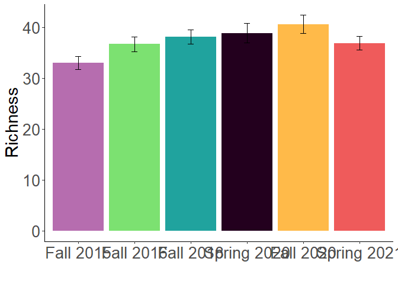

```r
year_richness<-bind_rows(list_richness_rare)


year_richness<-year_richness %>% filter(sample == 50)


ggplot(data = year_richness,aes(x=Year,y=Rarefaction,fill = Year))+
geom_bar(stat="identity")+geom_errorbar(aes(ymin=IC_low,ymax= IC_up),width =0.1)+
  scale_fill_manual(values = color_op6_l)+
  xlab("")+
  ylab('Richness')+
  theme_classic()+
    theme(axis.text.x = element_text(size=20),
        plot.title = element_text(size=24),
        axis.text.y = element_text(size =20),
        axis.title.x = element_text(size=22),
        axis.title.y = element_text(size=22),
        legend.title = element_text(size=22),
        legend.text = element_text(size=20),
        legend.position = "none",
        strip.text.x = element_text(size = 20))+
    scale_x_discrete(labels = c("Fall 2015","Fall 2016","Fall 2018","Spring 2020",
                                      "Fall 2020" ,
                                      "Spring 2021"))
```

```r
#ggsave("rare_richness_bar_15.png" , width = 7, height = 5, dpi = 300,path = save_path)
#ggsave("rare_richness_bar_15.pdf" , width = 7, height = 5, dpi = 300,path = save_path)
```

## abundance

*** still didnt change

```r
ind_per_m<- abundance %>%  group_by(Site,year_month,Knoll,Surface_Area) %>% summarise("inds"=sum(ind)) %>% mutate("inds_m"=inds/Surface_Area)
```

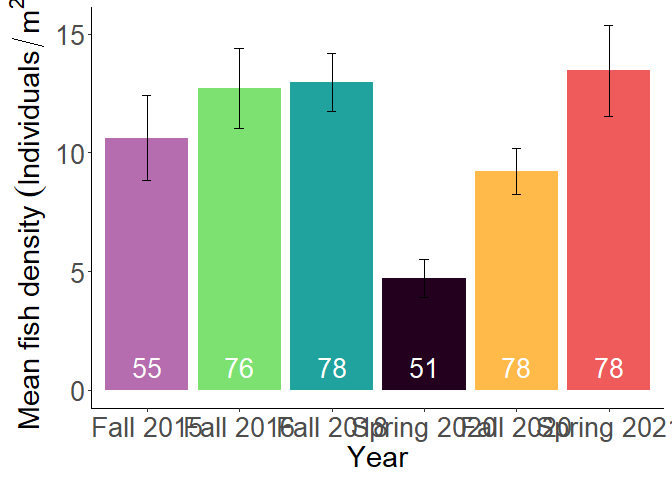

```r
ind_per_m <- ind_per_m %>%
  group_by(year_month) %>%
  summarise("mean_density"=mean(inds_m),                                  "se"= std.error(inds_m),
            "n"=n())


ggplot(data = ind_per_m,aes(x=year_month,y=mean_density,fill = year_month))+
geom_bar(stat="identity")+geom_errorbar(aes(ymin=mean_density-se,ymax=mean_density+se),width =0.1)+
  geom_text(aes(label = n,y=1), size = 7,color= "white")+
  xlab("Year")+
  ylab(bquote('Mean fish density '(Individuals/m^2)))+
  theme_classic()+
    theme(axis.text.x = element_text(size=20),
        plot.title = element_text(size=24),
        axis.text.y = element_text(size =20),
        axis.title.x = element_text(size=22),
        axis.title.y = element_text(size=22),
        legend.title = element_text(size=22),
        legend.text = element_text(size=20),
        legend.position = "none",
        strip.text.x = element_text(size = 20))+
  scale_fill_manual(values= color_op6_l,
                           name = "Year",
                           labels = c("Fall 2015","Fall 2016","Fall 2018","Spring 2020",
                                      "Fall 2020" ,
                                      "Spring 2021"))+
  scale_x_discrete(labels = c("Fall 2015","Fall 2016","Fall 2018","Spring 2020",
                                      "Fall 2020" ,
                                      "Spring 2021"))
```

```r
#ggsave("abundance_bar_15.png" , width = 7, height = 5, dpi = 300,path = save_path)
#ggsave("abundance_bar_15.pdf" , width = 7, height = 5, dpi = 300,path = save_path)
```

## shannon

sample based rarefaction for effective number of species by shannon index

```r
shannon_rare<-list()
loop<-1



for (i in unique(shannon$year_month)) {

  year<- shannon %>% filter(year_month == i)

  year_richness_shannon<-Rarefy::rare_alpha(year[13:ncol(year)],
                          method="hill",
                          q=1,
                          random=50,
                          mean = F)

  year_richness_shannon$Year<-rep(i)
  year_richness_shannon$sample<-1:nrow(year_richness_shannon)


  shannon_rare[[loop]]<-year_richness_shannon
  loop<-loop+1


}

richness_shannon<-bind_rows(shannon_rare)
```

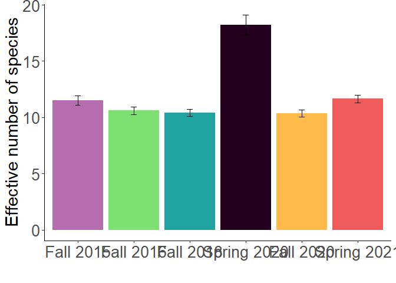

```r
richness_shannon<-richness_shannon %>% filter(sample == 50)


ggplot(data = richness_shannon,aes(x=Year,y=Rarefaction,fill = Year))+
geom_bar(stat="identity")+geom_errorbar(aes(ymin=IC_low,ymax= IC_up),width =0.1)+
  scale_fill_manual(values = color_op6_l)+
  xlab("")+
  ylab('Effective number of species')+
  theme_classic()+
    theme(axis.text.x = element_text(size=20),
        plot.title = element_text(size=24),
        axis.text.y = element_text(size =20),
        axis.title.x = element_text(size=22),
        axis.title.y = element_text(size=22),
        legend.title = element_text(size=22),
        legend.text = element_text(size=20),
        legend.position = "none",
        strip.text.x = element_text(size = 20))+
    scale_x_discrete(labels = c("Fall 2015","Fall 2016","Fall 2018","Spring 2020",
                                      "Fall 2020" ,
                                      "Spring 2021"))
```

```r
#ggsave("rare_shannon_bar_15.png" , width = 7, height = 5, dpi = 300,path = save_path)
#ggsave("rare_shannon_bar_15.pdf" , width = 7, height = 5, dpi = 300,path = save_path)
```